### *Sargassum horneri* occurence - southern California

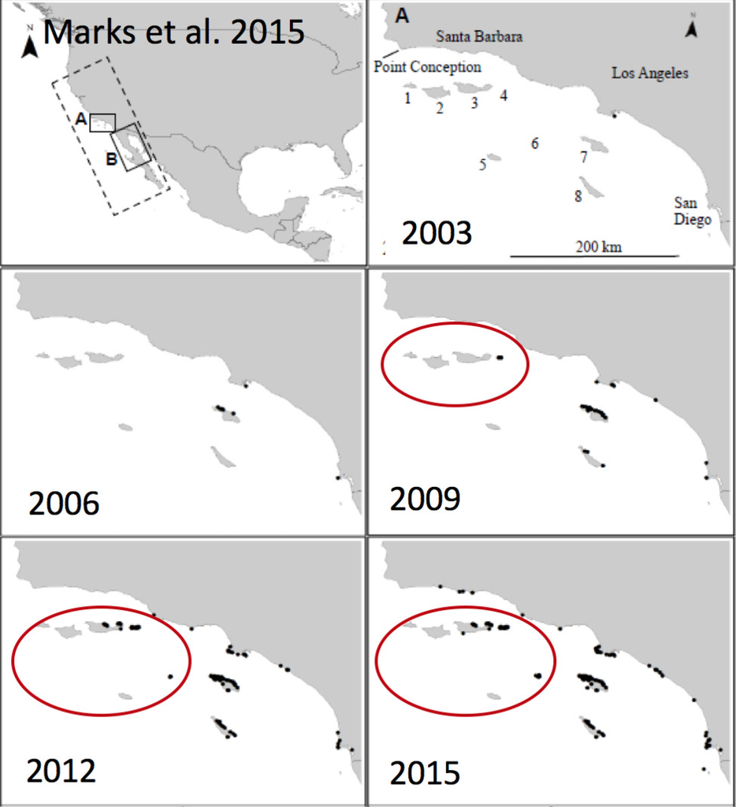

**Figure App.F.14.2.**. A map showing the expansion of the non-native alga *Sargassum horneri* in the Southern California Bight from 2003 - 2015.

**Click for Details**

First seen in Long Beach Harbor in 2003, *Sargassum horneri* had spread to many mainland and island sites in southern California by 2015. First observed in Channel Islands National Marine Sanctuary at Anacapa in 2009, it had expanded to both Santa Barbara and Santa Cruz islands by 2015. Red ovals highlight observations that are inside Channel Islands National Marine Sanctuary. Figure: Modified from Marks et al. 2015

### *Sargassum horneri* occurence - CINMS

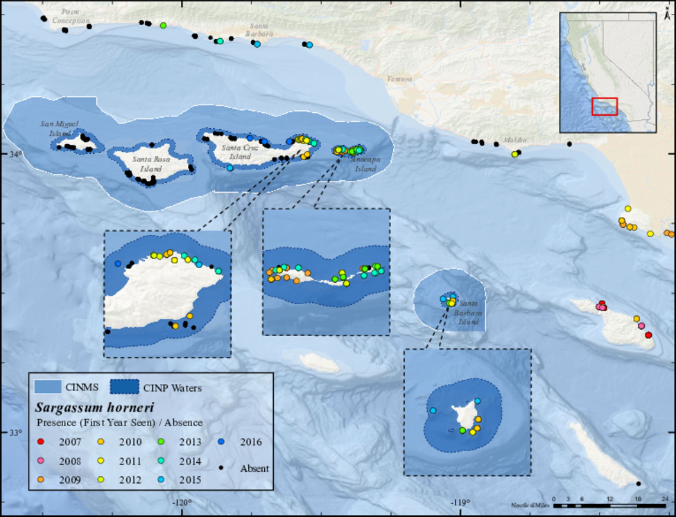

**Figure App.F.14.3.**. A map showing the locations where the non-native alga *Sargassum horneri* has been observed in the Southern California Bight.

**Click for Details**

Locations where the invasive alga *Sargassum horneri* has been observed in the Southern California Bight. The color of circles denote the year Sargassum was first seen while black circles indicate sites where it has not been observed. Note: This is a more detailed variant of a map that was shown during the expert workshop. Data source: [CINP](https://www.nps.gov/chis/index.htm),[PISCO](http://www.piscoweb.org/), and [SBC LTER](https://sbclter.msi.ucsb.edu/) data courtesy of L. Marks/ UCSB; Map: M. Cajandig/NOAA](https://channelislands.noaa.gov/contact/cajandig.html)

### *Sargassum horneri* percent cover by island

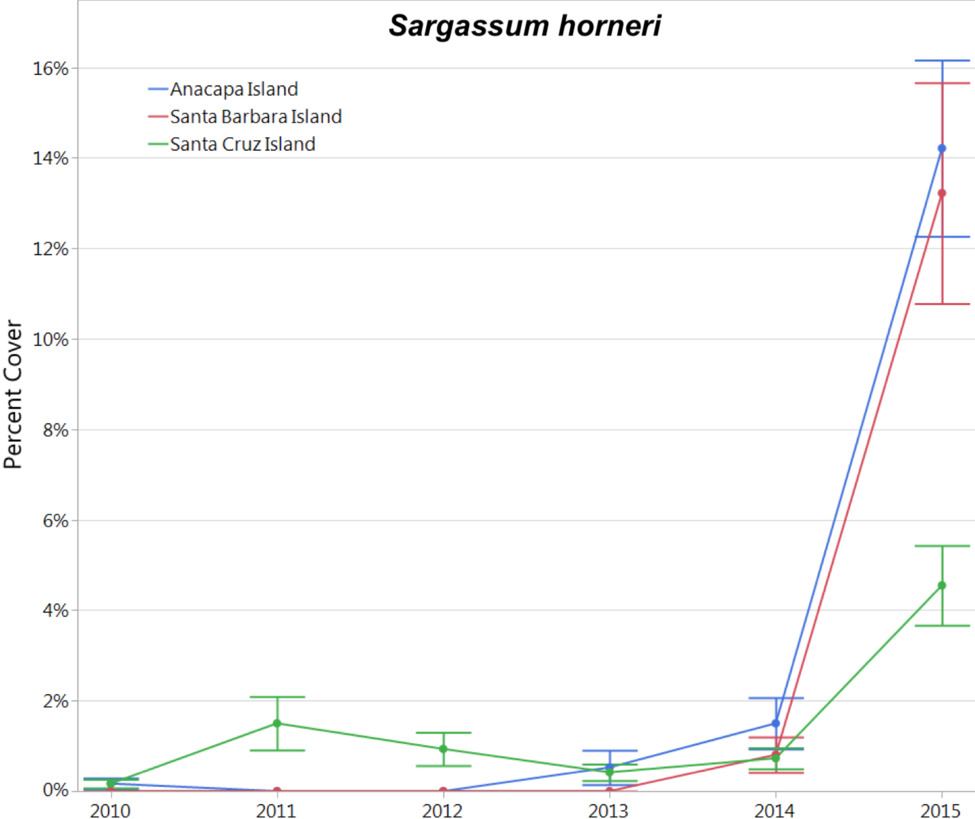

**Figure App.F.14.4.**. A figure showing the average amount of *Sargassum horneri* across three of the Nothern Channel Islands from 2010 - 2015.

**Click for Details**

Mean (+/- SE) percent cover of *Sargassum horneri* at sites monitored by Channel Islands National Park at Santa Cruz (green), Anacapa (blue), and Santa Barbara (red) islands. Cover has recently increased at all three islands. Figure: [Channel Islands National Park](https://www.nps.gov/chis/index.htm)

### *Watersipora* occurence - Southern California Bight

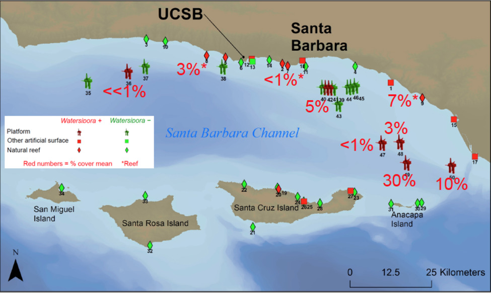

**Figure App.F.14.5.**. A map showing the presence (red) and absence (green) of a non-native encrusting invertebrate on oil platforms in the Santa Barbara Channel and around the Northern Channel Islands.

**Click for Details**